# Bank_Application

David Dominguez - A01570975

2024-03-10

# Bank Application Classification Models

## Instrucciones

A partir de la asignación durante la sesión de clase de las siguientes bases de datos i) bank_application_data o ii) bank_marketing_data, realizar las instrucciones 1 – 6. En el desarrollo del archivo de R-Markdown, por favor incluir data storytelling de los resultados del análisis exploratorio de los datos (EDA) así como la interpretación de los resultados estimados.

## Lectura Sugeridas:

- What is Classification in Machine Learning and Why Is It Important? https://emeritus.org/blog/artificial-intelligence-and-machine-learning-classification-in-machine- learning/
- 5 Classification Algorithms for Machine Learning https://builtin.com/data-science/supervised-machine-learning-classification
- What is K-Means Algorithm and How it Works? https://towardsmachinelearning.org/k-means/

## Glosario

- **SK_ID_CURR**: Identificador del préstamo en nuestra muestra.
- **TARGET**: Variable objetivo (1 - cliente con dificultades de pago: tuvo un pago tardío más de X días en al menos una de las primeras Y cuotas del préstamo en nuestra muestra, 0 - todos los demás casos).
- **NAME_CONTRACT_TYPE**: Identificación si el préstamo es en efectivo o revolving.
- **CODE_GENDER**: Género del cliente.
- **FLAG_OWN_CAR**: Indicador si el cliente posee un coche.
- **FLAG_OWN_REALTY**: Indicador si el cliente posee una casa o piso.
- **CNT_CHILDREN**: Número de hijos que tiene el cliente.
- **AMT_INCOME_TOTAL**: Ingresos del cliente.
- **AMT_CREDIT**: Monto del crédito del préstamo.
- **AMT_ANNUITY**: Anualidad del préstamo.
- **AMT_GOODS_PRICE**: Para los préstamos al consumo, es el precio de los bienes por los que se concedió el préstamo.
- **NAME_TYPE_SUITE**: Quién acompañaba al cliente cuando solicitaba el préstamo.
- **NAME_INCOME_TYPE**: Tipo de ingresos del cliente (empresario, trabajando, baja por maternidad,…).
- **NAME_EDUCATION_TYPE**: Nivel de educación más alto alcanzado por el cliente.
- **NAME_FAMILY_STATUS**: Estado familiar del cliente.
- **NAME_HOUSING_TYPE**: Cuál es la situación de vivienda del cliente (alquilando, viviendo con los padres, …).
- **REGION_POPULATION_RELATIVE**: Población normalizada de la región donde vive el cliente (un número más alto significa que el cliente vive en una región más poblada).
- **DAYS_BIRTH**: Edad del cliente en días en el momento de la solicitud.
- **DAYS_EMPLOYED**: Cuántos días antes de la solicitud comenzó el empleo actual la persona.
- **DAYS_REGISTRATION**: Cuántos días antes de la solicitud cambió el cliente su registro.
- **DAYS_ID_PUBLISH**: Cuántos días antes de la solicitud cambió el cliente el documento de identidad con el que solicitó el préstamo.
- **OWN_CAR_AGE**: Edad del coche del cliente.
- **FLAG_MOBIL**: Indicador si el cliente proporcionó teléfono móvil (1=SI, 0=NO).
- **FLAG_EMP_PHONE**: Indicador si el cliente proporcionó teléfono del trabajo (1=SI, 0=NO).
- **FLAG_WORK_PHONE**: Indicador si el cliente proporcionó teléfono fijo (1=SI, 0=NO).
- **FLAG_CONT_MOBILE**: Indicador si el teléfono móvil era alcanzable (1=SI, 0=NO).
- **FLAG_PHONE**: Indicador si el cliente proporcionó teléfono fijo (1=SI, 0=NO).
- **FLAG_EMAIL**: Indicador si el cliente proporcionó correo electrónico (1=SI, 0=NO).
- **OCCUPATION_TYPE**: Qué tipo de ocupación tiene el cliente.
- **CNT_FAM_MEMBERS**: Cuántos miembros de la familia tiene el cliente.
- **REGION_RATING_CLIENT**: Nuestra calificación de la región donde vive el cliente (1,2,3).
- **REGION_RATING_CLIENT_W_CITY**: Nuestra calificación de la región donde vive el cliente teniendo en cuenta la ciudad (1,2,3).
- **WEEKDAY_APPR_PROCESS_START**: En qué día de la semana el cliente solicitó el préstamo.
- **HOUR_APPR_PROCESS_START**: Aproximadamente a qué hora el cliente solicitó el préstamo.
- **REG_REGION_NOT_LIVE_REGION**: Indicador si la dirección permanente del cliente no coincide con la dirección de contacto (1=diferente, 0=igual, a nivel de región).
- **REG_REGION_NOT_WORK_REGION**: Indicador si la dirección permanente del cliente no coincide con la dirección de trabajo (1=diferente, 0=igual, a nivel de región).
- **LIVE_REGION_NOT_WORK_REGION**: Indicador si la dirección de contacto del cliente no coincide con la dirección de trabajo (1=diferente, 0=igual, a nivel de región).
- **REG_CITY_NOT_LIVE_CITY**: Indicador si la dirección permanente del cliente no coincide con la dirección de contacto (1=diferente, 0=igual, a nivel de ciudad).
- **REG_CITY_NOT_WORK_CITY**: Indicador si la dirección permanente del cliente no coincide con la dirección de trabajo (1=diferente, 0=igual, a nivel de ciudad).
- **LIVE_CITY_NOT_WORK_CITY**: Indicador si la dirección de contacto del cliente no coincide con la dirección de trabajo (1=diferente, 0=igual, a nivel de ciudad).
- **ORGANIZATION_TYPE**: Tipo de organización donde trabaja el cliente.
- **EXT_SOURCE_1**: Puntuación normalizada de fuente de datos externa.
- **EXT_SOURCE_2**: Puntuación normalizada de fuente de datos externa.
- **EXT_SOURCE_3**: Puntuación normalizada de fuente de datos externa.
- **APARTMENTS_AVG**: Información normalizada sobre el edificio donde vive el cliente, tamaño promedio del apartamento, área común, área habitable, edad del edificio, número de ascensores, número de entradas, estado del edificio, número de pisos.
- **BASEMENTAREA_AVG**: Información normalizada sobre el sótano del edificio donde vive el cliente.
- **YEARS_BEGINEXPLUATATION_AVG**: Información normalizada sobre el inicio de la explotación del edificio donde vive el cliente.
- **YEARS_BUILD_AVG**: Información normalizada sobre la antigüedad del edificio donde vive el cliente.
- **COMMONAREA_AVG**: Información normalizada sobre áreas comunes en el edificio donde vive el cliente.
- **ELEVATORS_AVG**: Información normalizada sobre ascensores en el edificio donde vive el cliente.
- **ENTRANCES_AVG**: Información normalizada sobre entradas en el edificio donde vive el cliente.
- **FLOORSMAX_AVG**: Información normalizada sobre el número máximo de pisos en el edificio donde vive el cliente.
- **FLOORSMIN_AVG**: Información normalizada sobre el número mínimo de pisos en el edificio donde vive el cliente.
- **LANDAREA_AVG**: Información normalizada sobre el área de terreno del edificio donde vive el cliente.
- **LIVINGAPARTMENTS_AVG**: Información normalizada sobre apartamentos habitables en el edificio donde vive el cliente.
- **LIVINGAREA_AVG**: Información normalizada sobre el área habitable en el edificio donde vive el cliente.
- **NONLIVINGAPARTMENTS_AVG**: Información normalizada sobre apartamentos no habitables en el edificio donde vive el cliente.
- **NONLIVINGAREA_AVG**: Información normalizada sobre áreas no habitables en el edificio donde vive el cliente.
- **APARTMENTS_MODE**: Modo de la información normalizada sobre apartamentos en el edificio donde vive el cliente.
- **BASEMENTAREA_MODE**: Modo de la información normalizada sobre el sótano del edificio donde vive el cliente.
- **YEARS_BEGINEXPLUATATION_MODE**: Modo de la información normalizada sobre el inicio de la explotación del edificio donde vive el cliente.
- **YEARS_BUILD_MODE**: Modo de la información normalizada sobre la antigüedad del edificio donde vive el cliente.
- **COMMONAREA_MODE**: Modo de la información normalizada sobre áreas comunes en el edificio donde vive el cliente.
- **ELEVATORS_MODE**: Modo de la información normalizada sobre ascensores en el edificio donde vive el cliente.
- **ENTRANCES_MODE**: Modo de la información normalizada sobre entradas en el edificio donde vive el cliente.
- **FLOORSMAX_MODE**: Modo de la información normalizada sobre el número máximo de pisos en el edificio donde vive el cliente.
- **FLOORSMIN_MODE**: Modo de la información normalizada sobre el número mínimo de pisos en el edificio donde vive el cliente.
- **LANDAREA_MODE**: Modo de la información normalizada sobre el área de terreno del edificio donde vive el cliente.
- **LIVINGAPARTMENTS_MODE**: Modo de la información normalizada sobre apartamentos habitables en el edificio donde vive el cliente.
- **LIVINGAREA_MODE**: Modo de la información normalizada sobre el área habitable en el edificio donde vive el cliente.
- **NONLIVINGAPARTMENTS_MODE**: Modo de la información normalizada sobre apartamentos no habitables en el edificio donde vive el cliente.
- **NONLIVINGAREA_MODE**: Modo de la información normalizada sobre áreas no habitables en el edificio donde vive el cliente.
- **APARTMENTS_MEDI**: Mediana de la información normalizada sobre apartamentos en el edificio donde vive el cliente.
- **BASEMENTAREA_MEDI**: Mediana de la información normalizada sobre el sótano del edificio donde vive el cliente.
- **YEARS_BEGINEXPLUATATION_MEDI**: Mediana de la información normalizada sobre el inicio de la explotación del edificio donde vive el cliente.
- **YEARS_BUILD_MEDI**: Mediana de la información normalizada sobre la antigüedad del edificio donde vive el cliente.
- **COMMONAREA_MEDI**: Mediana de la información normalizada sobre áreas comunes en el edificio donde vive el cliente.
- **ELEVATORS_MEDI**: Mediana de la información normalizada sobre ascensores en el edificio donde vive el cliente.
- **ENTRANCES_MEDI**: Mediana de la información normalizada sobre entradas en el edificio donde vive el cliente.
- **FLOORSMAX_MEDI**: Mediana de la información normalizada sobre el número máximo de pisos en el edificio donde vive el cliente.
- **FLOORSMIN_MEDI**: Mediana de la información normalizada sobre el número mínimo de pisos en el edificio donde vive el cliente.
- **LANDAREA_MEDI**: Mediana de la información normalizada sobre el área de terreno del edificio donde vive el cliente.
- **LIVINGAPARTMENTS_MEDI**: Mediana de la información normalizada sobre apartamentos habitables en el edificio donde vive el cliente.
- **LIVINGAREA_MEDI**: Mediana de la información normalizada sobre el área habitable en el edificio donde vive el cliente.
- **NONLIVINGAPARTMENTS_MEDI**: Mediana de la información normalizada sobre apartamentos no habitables en el edificio donde vive el cliente.
- **NONLIVINGAREA_MEDI**: Mediana de la información normalizada sobre áreas no habitables en el edificio donde vive el cliente.
- **FONDKAPREMONT_MODE**: Modo de la información normalizada sobre el fondo de reparación del edificio donde vive el cliente.
- **HOUSETYPE_MODE**: Modo de la información normalizada sobre el tipo de casa donde vive el cliente.
- **TOTALAREA_MODE**: Modo de la información normalizada sobre el área total del edificio donde vive el cliente.
- **WALLSMATERIAL_MODE**: Modo de la información normalizada sobre el material de las paredes del edificio donde vive el cliente.
- **EMERGENCYSTATE_MODE**: Modo de la información normalizada sobre el estado de emergencia del edificio donde vive el cliente.
- **OBS_30_CNT_SOCIAL_CIRCLE**: Cuántas observaciones del entorno social del cliente con 30 DPD (días de mora) por defecto.
- **DEF_30_CNT_SOCIAL_CIRCLE**: Cuántas observaciones del entorno social del cliente incumplieron en 30 DPD (días de mora).
- **OBS_60_CNT_SOCIAL_CIRCLE**: Cuántas observaciones del entorno social del cliente con 60 DPD (días de mora) por defecto.
- **DEF_60_CNT_SOCIAL_CIRCLE**: Cuántas observaciones del entorno social del cliente incumplieron en 60 DPD (días de mora).
- **DAYS_LAST_PHONE_CHANGE**: Cuántos días antes de la solicitud el cliente cambió de teléfono.
- **FLAG_DOCUMENT_2** a **FLAG_DOCUMENT_21**: Indicadores si el cliente proporcionó documentos específicos (2 a 21).
- **AMT_REQ_CREDIT_BUREAU_HOUR**: Número de consultas al Buró de Crédito sobre el cliente una hora antes de la solicitud.
- **AMT_REQ_CREDIT_BUREAU_DAY**: Número de consultas al Buró de Crédito sobre el cliente un día antes de la solicitud (excluyendo una hora antes de la solicitud).
- **AMT_REQ_CREDIT_BUREAU_WEEK**: Número de consultas al Buró de Crédito sobre el cliente una semana antes de la solicitud (excluyendo un día antes de la solicitud).
- **AMT_REQ_CREDIT_BUREAU_MON**: Número de consultas al Buró de Crédito sobre el cliente un mes antes de la solicitud (excluyendo una semana antes de la solicitud).
- **AMT_REQ_CREDIT_BUREAU_QRT**: Número de consultas al Buró de Crédito sobre el cliente 3 meses antes de la solicitud (excluyendo un mes antes de la solicitud).
- **AMT_REQ_CREDIT_BUREAU_YEAR**: Número de consultas al Buró de Crédito sobre el cliente un año antes de la solicitud (excluyendo los últimos 3 meses antes de la solicitud).

## Teoría

**Brevemente responder con tus propias palabras 2 de las siguientes 3 preguntas:**

- 1. ¿Qué es Supervised Machine Learning y cuáles son algunas de sus aplicaciones en análisis de clasificación?

El **aprendizaje supervisado** o **Supervised Machine Learning** es una categoría del machine learning donde el modelo se entrena con un conjunto de datos etiquetados, es decir, para cada entrada en el conjunto de entrenamiento, ya conocemos la salida correcta. El objetivo es que el modelo aprenda a predecir la salida para nuevas entradas basándose en esta experiencia de entrenamiento. En análisis de clasificación, se utiliza para predecir la categoría o clase a la que pertenece una nueva entrada. Algunas aplicaciones incluyen:

- Detección de spam en correos electrónicos.
- Diagnóstico médico.
- Reconocimiento de imágenes.
- Detección de fraude en transacciones.
- 2. ¿Cuáles son los principales algoritmos de Supervised Machine Learning - Classification? Brevemente describir con tus propias palarbas 4 – 6 de los principales algoritmos de Supervised Machine Learning - Classification.

Hay varios modelos en el universo de la clasificación supervisada, cada uno con su propia fortaleza:

- **Regresión Logística:** Utilizada para clasificación binaria, modela la probabilidad de que una entrada pertenezca a una clase específica.
- **K-Nearest Neighbors (KNN):** Clasifica una entrada basándose en las clases de sus ‘K’ vecinos más cercanos.
- **Máquinas de Vector Soporte (SVM):** Busca el hiperplano que mejor separa las clases en el espacio de características.
- **Árboles de Decisión:** Construye un árbol donde cada nodo representa una característica y cada hoja una clase.
- **Bosques Aleatorios:** Un ensamble de múltiples árboles de decisión para mejorar la estabilidad y precisión.
- **Redes Neuronales Artificiales:** Aprenden patrones complejos y son potentes para clasificación en datasets grandes y complejos.
- 3. Respecto a la selección de los resultados de los modelos de clasificación ¿Qué es la matriz de confusión? ¿Qué es el estadístico Kappa? ¿Cuál es la relación entre AUC y ROC Curve?
- **Matriz de confusión:** Herramienta que muestra el número de predicciones correctas e incorrectas divididas en categorías.
- **Estadístico Kappa:** Evalúa la precisión de una clasificación considerando la coincidencia que podría suceder por puro azar.
- **Relación entre AUC y ROC Curve:** La curva ROC evalúa cómo de bien un modelo distingue entre categorías a distintos niveles de decisión. AUC, el área bajo esta curva, resume en un número cuán efectivo es el modelo.

## Obtención de Data

```r
library(readr)
library(dplyr)
library(tidyverse)
library(tidyr)
library(purrr)
library(scales)
library(ggplot2)
library(GGally)
library(corrplot)
library(caret)
library(pROC)
library(rpart)
library(rpart.plot)
library(e1071)
library(cluster)
library(factoextra)
library(class)
library(randomForest)
```

```r
bank_application <- read_csv("bank_application_data.csv")
head(bank_application)
```

```
## # A tibble: 6 × 122
##   SK_ID_CURR TARGET NAME_CONTRACT_TYPE CODE_GENDER FLAG_OWN_CAR FLAG_OWN_REALTY
##        <dbl>  <dbl> <chr>              <chr>       <chr>        <chr>
## 1     100002      1 Cash loans         M           N            Y
## 2     100003      0 Cash loans         F           N            N
## 3     100004      0 Revolving loans    M           Y            Y
## 4     100006      0 Cash loans         F           N            Y
## 5     100007      0 Cash loans         M           N            Y
## 6     100008      0 Cash loans         M           N            Y
## # ℹ 116 more variables: CNT_CHILDREN <dbl>, AMT_INCOME_TOTAL <dbl>,
## #   AMT_CREDIT <dbl>, AMT_ANNUITY <dbl>, AMT_GOODS_PRICE <dbl>,
## #   NAME_TYPE_SUITE <chr>, NAME_INCOME_TYPE <chr>, NAME_EDUCATION_TYPE <chr>,
## #   NAME_FAMILY_STATUS <chr>, NAME_HOUSING_TYPE <chr>,
## #   REGION_POPULATION_RELATIVE <dbl>, DAYS_BIRTH <dbl>, DAYS_EMPLOYED <dbl>,
## #   DAYS_REGISTRATION <dbl>, DAYS_ID_PUBLISH <dbl>, OWN_CAR_AGE <dbl>,
## #   FLAG_MOBIL <dbl>, FLAG_EMP_PHONE <dbl>, FLAG_WORK_PHONE <dbl>, …
```

## Preparación y Analisis Exploratorio

**Desarrollar Análisis Exploratorio de los Datos (EDA) que incluye los siguientes elementos:**

### a. Identificación de NA’s

```r
# Contar el total de NA's en todo el dataframe
total_NA <- sum(is.na(bank_application))
print(paste("Total de NA's en el dataframe: ", total_NA))
```

```
## [1] "Total de NA's en el dataframe:  9152465"
```

```r
# Contar NA's por cada columna y mostrar el resultado
NA_por_columna <- sapply(bank_application, function(x) sum(is.na(x)))
print("NA's por columna:")
```

```
## [1] "NA's por columna:"
```

```r
print(NA_por_columna)
```

```
##                   SK_ID_CURR                       TARGET
##                            0                            0
##           NAME_CONTRACT_TYPE                  CODE_GENDER
##                            0                            0
##                 FLAG_OWN_CAR              FLAG_OWN_REALTY
##                            0                            0
##                 CNT_CHILDREN             AMT_INCOME_TOTAL
##                            0                            0
##                   AMT_CREDIT                  AMT_ANNUITY
##                            0                           12
##              AMT_GOODS_PRICE              NAME_TYPE_SUITE
##                          278                         1292
##             NAME_INCOME_TYPE          NAME_EDUCATION_TYPE
##                            0                            0
##           NAME_FAMILY_STATUS            NAME_HOUSING_TYPE
##                            0                            0
##   REGION_POPULATION_RELATIVE                   DAYS_BIRTH
##                            0                            0
##                DAYS_EMPLOYED            DAYS_REGISTRATION
##                            0                            0
##              DAYS_ID_PUBLISH                  OWN_CAR_AGE
##                            0                       202929
##                   FLAG_MOBIL               FLAG_EMP_PHONE
##                            0                            0
##              FLAG_WORK_PHONE             FLAG_CONT_MOBILE
##                            0                            0
##                   FLAG_PHONE                   FLAG_EMAIL
##                            0                            0
##              OCCUPATION_TYPE              CNT_FAM_MEMBERS
##                        96391                            2
##         REGION_RATING_CLIENT  REGION_RATING_CLIENT_W_CITY
##                            0                            0
##   WEEKDAY_APPR_PROCESS_START      HOUR_APPR_PROCESS_START
##                            0                            0
##   REG_REGION_NOT_LIVE_REGION   REG_REGION_NOT_WORK_REGION
##                            0                            0
##  LIVE_REGION_NOT_WORK_REGION       REG_CITY_NOT_LIVE_CITY
##                            0                            0
##       REG_CITY_NOT_WORK_CITY      LIVE_CITY_NOT_WORK_CITY
##                            0                            0
```

[output cut: 67 more lines]

```
##                            0                            0
##             FLAG_DOCUMENT_14             FLAG_DOCUMENT_15
##                            0                            0
##             FLAG_DOCUMENT_16             FLAG_DOCUMENT_17
##                            0                            0
##             FLAG_DOCUMENT_18             FLAG_DOCUMENT_19
##                            0                            0
##             FLAG_DOCUMENT_20             FLAG_DOCUMENT_21
##                            0                            0
##   AMT_REQ_CREDIT_BUREAU_HOUR    AMT_REQ_CREDIT_BUREAU_DAY
##                        41519                        41519
##   AMT_REQ_CREDIT_BUREAU_WEEK    AMT_REQ_CREDIT_BUREAU_MON
##                        41519                        41519
##    AMT_REQ_CREDIT_BUREAU_QRT   AMT_REQ_CREDIT_BUREAU_YEAR
##                        41519                        41519
```

### b. Reemplazo de NA’s

```r
# Función para calcular la moda, ajustada para trabajar con caracteres directamente
getMode <- function(v) {
  uniqv <- unique(v)
  uniqv[which.max(tabulate(match(v, uniqv)))]
}

# Función ajustada para reemplazar NA's, incluyendo columnas de caracteres
replace_NA_adjusted <- function(df) {
  df <- df %>%
    mutate(across(where(is.numeric), ~ifelse(is.na(.), median(., na.rm = TRUE), .))) %>%
    mutate(across(where(is.character), function(x) {
      mode_value <- getMode(x[!is.na(x)])
      ifelse(is.na(x), mode_value, x)
    }))

  return(df)
}

# Aplicar la función ajustada al dataframe
bank_application <- replace_NA_adjusted(bank_application)

# Verificar el total de NA's después de la imputación
total_NA_after <- sum(is.na(bank_application))

print(paste("Total de NA's después de la imputación: ", total_NA_after))
```

```
## [1] "Total de NA's después de la imputación:  0"
```

### c. Medidas descriptivas

```r
# Medidas descriptivas básicas
summary(bank_application)
```

```
##    SK_ID_CURR         TARGET        NAME_CONTRACT_TYPE CODE_GENDER
##  Min.   :100002   Min.   :0.00000   Length:307511      Length:307511
##  1st Qu.:189146   1st Qu.:0.00000   Class :character   Class :character
##  Median :278202   Median :0.00000   Mode  :character   Mode  :character
##  Mean   :278180   Mean   :0.08073
##  3rd Qu.:367142   3rd Qu.:0.00000
##  Max.   :456255   Max.   :1.00000
##  FLAG_OWN_CAR       FLAG_OWN_REALTY     CNT_CHILDREN     AMT_INCOME_TOTAL
##  Length:307511      Length:307511      Min.   : 0.0000   Min.   :    25650
##  Class :character   Class :character   1st Qu.: 0.0000   1st Qu.:   112500
##  Mode  :character   Mode  :character   Median : 0.0000   Median :   147150
##                                        Mean   : 0.4171   Mean   :   168798
##                                        3rd Qu.: 1.0000   3rd Qu.:   202500
##                                        Max.   :19.0000   Max.   :117000000
##    AMT_CREDIT       AMT_ANNUITY     AMT_GOODS_PRICE   NAME_TYPE_SUITE
##  Min.   :  45000   Min.   :  1616   Min.   :  40500   Length:307511
##  1st Qu.: 270000   1st Qu.: 16524   1st Qu.: 238500   Class :character
##  Median : 513531   Median : 24903   Median : 450000   Mode  :character
##  Mean   : 599026   Mean   : 27108   Mean   : 538316
##  3rd Qu.: 808650   3rd Qu.: 34596   3rd Qu.: 679500
##  Max.   :4050000   Max.   :258026   Max.   :4050000
##  NAME_INCOME_TYPE   NAME_EDUCATION_TYPE NAME_FAMILY_STATUS NAME_HOUSING_TYPE
##  Length:307511      Length:307511       Length:307511      Length:307511
##  Class :character   Class :character    Class :character   Class :character
##  Mode  :character   Mode  :character    Mode  :character   Mode  :character
##
##
##
##  REGION_POPULATION_RELATIVE   DAYS_BIRTH     DAYS_EMPLOYED    DAYS_REGISTRATION
##  Min.   :0.00029            Min.   :-25229   Min.   :-17912   Min.   :-24672
##  1st Qu.:0.01001            1st Qu.:-19682   1st Qu.: -2760   1st Qu.: -7480
##  Median :0.01885            Median :-15750   Median : -1213   Median : -4504
##  Mean   :0.02087            Mean   :-16037   Mean   : 63815   Mean   : -4986
##  3rd Qu.:0.02866            3rd Qu.:-12413   3rd Qu.:  -289   3rd Qu.: -2010
##  Max.   :0.07251            Max.   : -7489   Max.   :365243   Max.   :     0
##  DAYS_ID_PUBLISH  OWN_CAR_AGE      FLAG_MOBIL FLAG_EMP_PHONE   FLAG_WORK_PHONE
##  Min.   :-7197   Min.   : 0.00   Min.   :0    Min.   :0.0000   Min.   :0.0000
##  1st Qu.:-4299   1st Qu.: 9.00   1st Qu.:1    1st Qu.:1.0000   1st Qu.:0.0000
##  Median :-3254   Median : 9.00   Median :1    Median :1.0000   Median :0.0000
##  Mean   :-2994   Mean   :10.04   Mean   :1    Mean   :0.8199   Mean   :0.1994
```

[output cut: 190 more lines]

```
##  Max.   :4.000000           Max.   :9.000000
##  AMT_REQ_CREDIT_BUREAU_WEEK AMT_REQ_CREDIT_BUREAU_MON AMT_REQ_CREDIT_BUREAU_QRT
##  Min.   :0.00000            Min.   : 0.0000           Min.   :  0.0000
##  1st Qu.:0.00000            1st Qu.: 0.0000           1st Qu.:  0.0000
##  Median :0.00000            Median : 0.0000           Median :  0.0000
##  Mean   :0.02972            Mean   : 0.2313           Mean   :  0.2296
##  3rd Qu.:0.00000            3rd Qu.: 0.0000           3rd Qu.:  0.0000
##  Max.   :8.00000            Max.   :27.0000           Max.   :261.0000
##  AMT_REQ_CREDIT_BUREAU_YEAR
##  Min.   : 0.000
##  1st Qu.: 1.000
##  Median : 1.000
##  Mean   : 1.778
##  3rd Qu.: 3.000
##  Max.   :25.000
```

**Insights de Analisis Descriptivo** - **TARGET**: La mayoría de los préstamos en la muestra no presentan dificultades de pago (el 92% tienen un TARGET de 0). - **CNT_CHILDREN**: La distribución muestra que la mayoría de los clientes no tienen hijos, con una mediana de 0. Sin embargo, hay casos con hasta 19 hijos, lo cual es inusual y podría ser un outlier. - **AMT_INCOME_TOTAL**: Existe una gran variabilidad en los ingresos de los clientes, desde un mínimo de 25,650 hasta un máximo de 117,000,000. Esto sugiere una alta disparidad económica entre los solicitantes de préstamos. - **DAYS_EMPLOYED**: El valor máximo es 365,243 días (aproximadamente 1000 años), lo cual es claramente un error o un valor utilizado para indicar un tipo específico de desempleo o condición laboral no tradicional. - **OWN_CAR_AGE**: La edad del coche tiene un máximo de 91 años, lo cual es poco común y podría indicar algunos valores atípicos o errores en los datos. - **EXT_SOURCE_2 y EXT_SOURCE_3**: Estas fuentes externas de puntaje tienen valores mínimos cercanos a 0 y máximos cercanos a 1, lo que indica que están normalizadas y podrían representar algún tipo de calificación de crédito o puntaje de riesgo. - **AMT_REQ_CREDIT_BUREAU_QRT**: Algunos clientes tienen hasta 261 consultas en el último trimestre, lo que es extremadamente alto y puede indicar un comportamiento de búsqueda de crédito muy activo o un posible error en los datos.

### d. Medidas de dispersión

```r
# Obtener solo las columnas numéricas
numeric_vars <- bank_application %>% select(where(is.numeric))

# Inicializar un data frame para almacenar los resultados finales
resultados_finales <- data.frame(Variable = names(numeric_vars))

# Funciones para calcular las medidas de dispersión
calculate_measures <- function(data, var_name) {
  data_frame <- tibble(
    Variable = var_name,
    Min = min(data[[var_name]], na.rm = TRUE),
    Max = max(data[[var_name]], na.rm = TRUE),
    Varianza = var(data[[var_name]], na.rm = TRUE),
    DesviacionStd = sd(data[[var_name]], na.rm = TRUE),
    IQR = IQR(data[[var_name]], na.rm = TRUE)
  )
  return(data_frame)
}

# Calcular medidas para cada variable numérica y almacenar en una lista
measures_list <- lapply(names(numeric_vars), calculate_measures, data = numeric_vars)

# Combinar los data frames de la lista en un único data frame
resultados_finales <- do.call(rbind, measures_list)

# Función personalizada para ajustar el formateo
format_custom <- function(x) {
  ifelse(abs(x) >= 1e7,
         format(x, scientific = TRUE),
         scales::number(x, accuracy = 0.1))
}

# Aplicar la función personalizada para cada columna numérica
resultados_finales <- resultados_finales %>%
  mutate(across(where(is.numeric), ~format_custom(.x)))

# Ver los resultados
print(resultados_finales)
```

```
## # A tibble: 106 × 6
##    Variable                   Min       Max         Varianza DesviacionStd IQR
##    <chr>                      <chr>     <chr>       <chr>    <chr>         <chr>
##  1 SK_ID_CURR                 100 002.0 "456 255.0" 1.05658… 102 790.2     177 …
##  2 TARGET                     0.0       "1.0"       0.1      0.3           0.0
##  3 CNT_CHILDREN               0.0       "19.0"      0.5      0.7           1.0
##  4 AMT_INCOME_TOTAL           25 650.0  " 1.170000… 5.62273… 237 123.1     90 0…
##  5 AMT_CREDIT                 45 000.0  "4 050 000… 1.61998… 402 490.8     538 …
##  6 AMT_ANNUITY                1 615.5   "258 025.5" 2.10060… 14 493.5      18 0…
##  7 AMT_GOODS_PRICE            40 500.0  "4 050 000… 1.36374… 369 289.0     441 …
##  8 REGION_POPULATION_RELATIVE 0.0       "0.1"       0.0      0.0           0.0
##  9 DAYS_BIRTH                 -25 229.0 "-7 489.0"  1.90444… 4 364.0       7 26…
## 10 DAYS_EMPLOYED              -17 912.0 "365 243.0" 1.99588… 141 275.8     2 47…
## # ℹ 96 more rows
```

**Insights de Medidas de Dispersión**

- **Ingresos Totales (AMT_INCOME_TOTAL)**: Hay una variabilidad significativa en los ingresos totales, con un máximo extremadamente alto de 117,000,000, lo que indica la presencia de outliers muy alejados del ingreso medio.
- **Cantidad de Crédito (AMT_CREDIT)**: La cantidad de crédito también muestra una amplia dispersión, desde 45,000 hasta 4,050,000, reflejando la diversidad en las necesidades de financiamiento de los solicitantes.
- **Días Empleados (DAYS_EMPLOYED)**: La variable días empleados incluye un valor máximo de 365,243, lo que sugiere un valor especial o un placeholder para ciertas situaciones, como el desempleo o la jubilación.
- **Solicitudes al Buró de Crédito (AMT_REQ_CREDIT_BUREAU_QRT)**: Algunos solicitantes tienen hasta 261 consultas en el último trimestre, lo que podría indicar un comportamiento de búsqueda de crédito muy activo o posibles errores en los datos.
- **Distribución de TARGET**: La mayoría de los solicitantes no tienen dificultades de pago (TARGET = 0), pero hay una variabilidad presente con un pequeño porcentaje que sí las tiene (TARGET = 1), lo que es crucial para el análisis de riesgo de crédito.

### e. Transformación Necesaria

**Limpieza de datos atípicos extremos**

```r
# Convertir valores negativos a positivos para DAYS_BIRTH y DAYS_EMPLOYED
bank_application <- bank_application %>%
  mutate(
    DAYS_BIRTH = abs(DAYS_BIRTH),
    DAYS_EMPLOYED = abs(DAYS_EMPLOYED)
  )

# Función para reemplazar outliers extremos con medianas
replace_extreme_outliers <- function(df, variable_name) {
  variable <- df[[variable_name]]
  median_value <- median(variable, na.rm = TRUE)
  sd_value <- sd(variable, na.rm = TRUE)
  mean_value <- mean(variable, na.rm = TRUE)

  # Definir límites para considerar un valor como outlier
  lower_limit <- mean_value - 3 * sd_value
  upper_limit <- mean_value + 3 * sd_value

  # Reemplazar outliers
  variable[variable < lower_limit | variable > upper_limit] <- median_value
  return(variable)
}

# Lista de variables para revisar y reemplazar outliers
variables_to_check <- c("AMT_INCOME_TOTAL", "AMT_CREDIT", "AMT_ANNUITY", "AMT_GOODS_PRICE",
                        "OWN_CAR_AGE", "DAYS_EMPLOYED", "DAYS_REGISTRATION",
                        "DAYS_ID_PUBLISH", "OBS_30_CNT_SOCIAL_CIRCLE",
                        "AMT_REQ_CREDIT_BUREAU_YEAR")

# Aplicar la función a cada variable en la lista
for (variable_name in variables_to_check) {
  bank_application[[variable_name]] <- replace_extreme_outliers(bank_application, variable_name)
}
```

### f. Identificación de patrones y/o tendencias en los datos mediante el uso de gráficos incluyendo bar plots, line plots, pie plots, histogramas, matriz de correlación, box plot, scatter plot, qq-

plot, etc Mostrar al menos 4 – 6 gráficos.

#### 1. Histograma de Edad

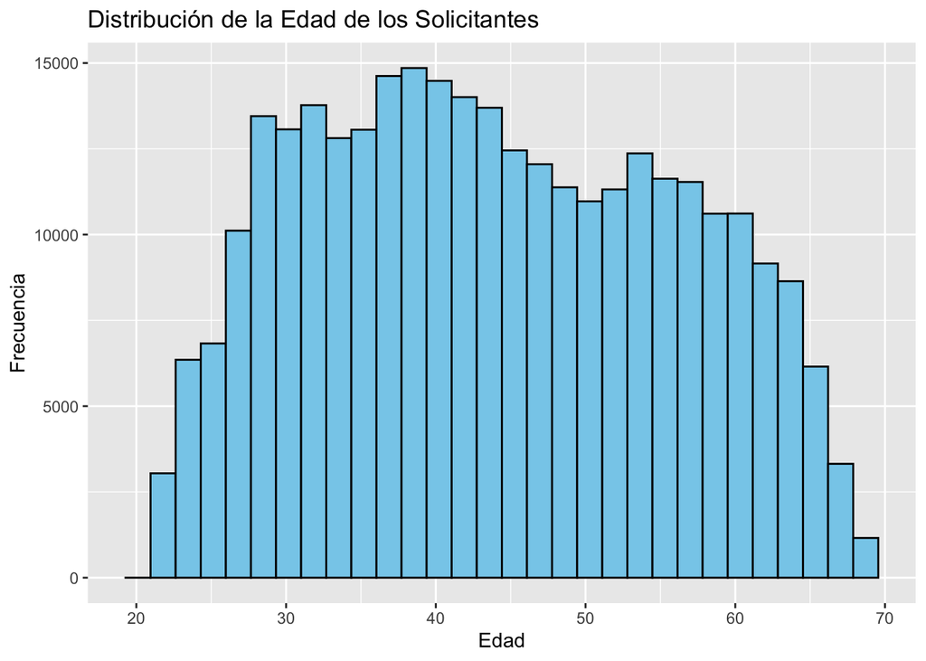

```r
ggplot(bank_application, aes(x = DAYS_BIRTH / 365)) +
  geom_histogram(bins = 30, fill = "skyblue", color = "black") +
  xlab("Edad") + ylab("Frecuencia") +
  ggtitle("Distribución de la Edad de los Solicitantes")
```

#### 2. Box Plot de Ingresos Totales

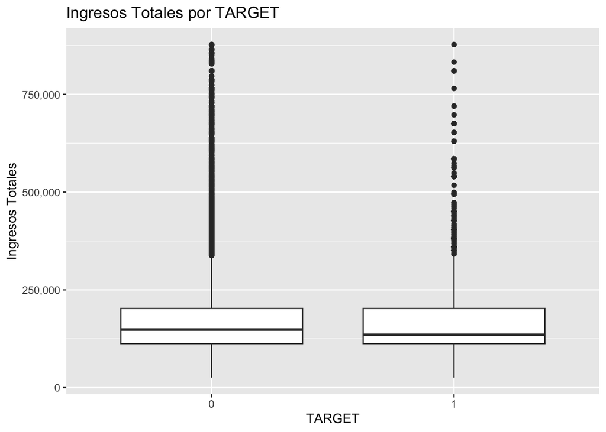

```r
ggplot(bank_application, aes(x = factor(TARGET), y = AMT_INCOME_TOTAL)) +
  geom_boxplot() +
  scale_y_continuous(labels = scales::comma) +
  xlab("TARGET") + ylab("Ingresos Totales") +
  ggtitle("Ingresos Totales por TARGET")
```

#### 3. Gráfico de Barras del Número de Hijos

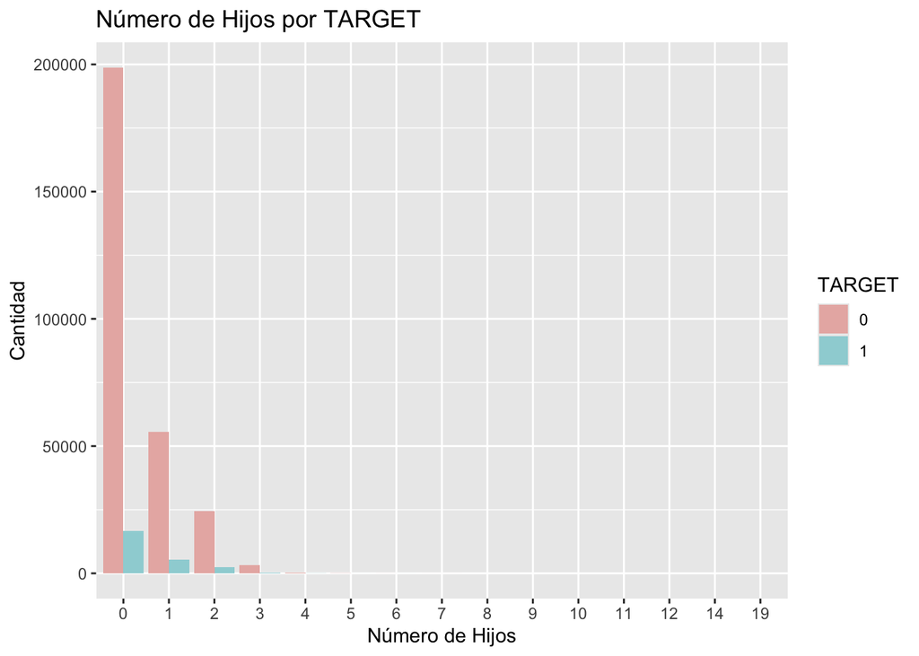

```r
ggplot(bank_application, aes(x = factor(CNT_CHILDREN), fill = factor(TARGET))) +
  geom_bar(position = "dodge") +
  xlab("Número de Hijos") + ylab("Cantidad") +
  ggtitle("Número de Hijos por TARGET") +
  scale_fill_manual(name = "TARGET", values = c("0" = "#e8b5b1", "1" = "#9ed3d7"))
```

#### 4. Matriz de Correlación

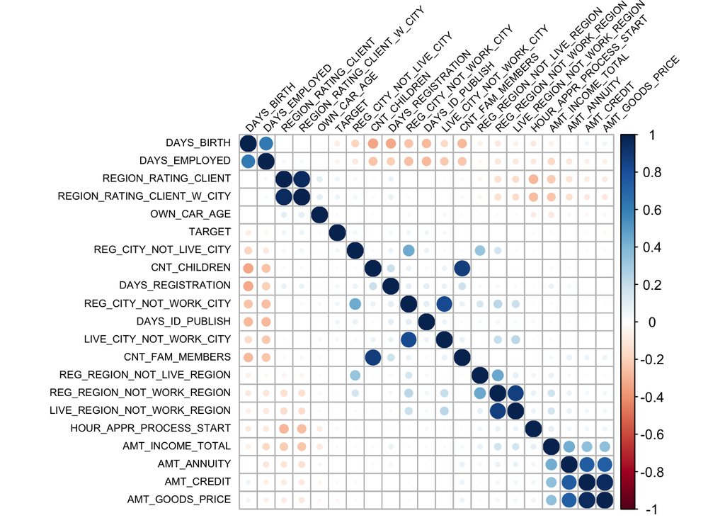

```r
df_cor <- bank_application %>%
  select(
    TARGET, AMT_INCOME_TOTAL, AMT_CREDIT, AMT_ANNUITY, AMT_GOODS_PRICE,
    DAYS_BIRTH, DAYS_EMPLOYED, DAYS_REGISTRATION, DAYS_ID_PUBLISH,
    OWN_CAR_AGE, CNT_CHILDREN, CNT_FAM_MEMBERS,
    REGION_RATING_CLIENT, REGION_RATING_CLIENT_W_CITY, HOUR_APPR_PROCESS_START,
    REG_REGION_NOT_LIVE_REGION, REG_REGION_NOT_WORK_REGION, LIVE_REGION_NOT_WORK_REGION,
    REG_CITY_NOT_LIVE_CITY, REG_CITY_NOT_WORK_CITY, LIVE_CITY_NOT_WORK_CITY
  ) %>%
  na.omit()

# Calculando la matriz de correlación
cor_matrix <- cor(df_cor)

# Visualizando la matriz de correlación con corrplot usando order = 'AOE'
corrplot(cor_matrix, order = 'AOE', method = "circle",
         tl.cex = 0.6, tl.col = "black", tl.srt = 45)
```

#### 5. Relación entre Ingresos Totales y Monto del Crédito por TARGET

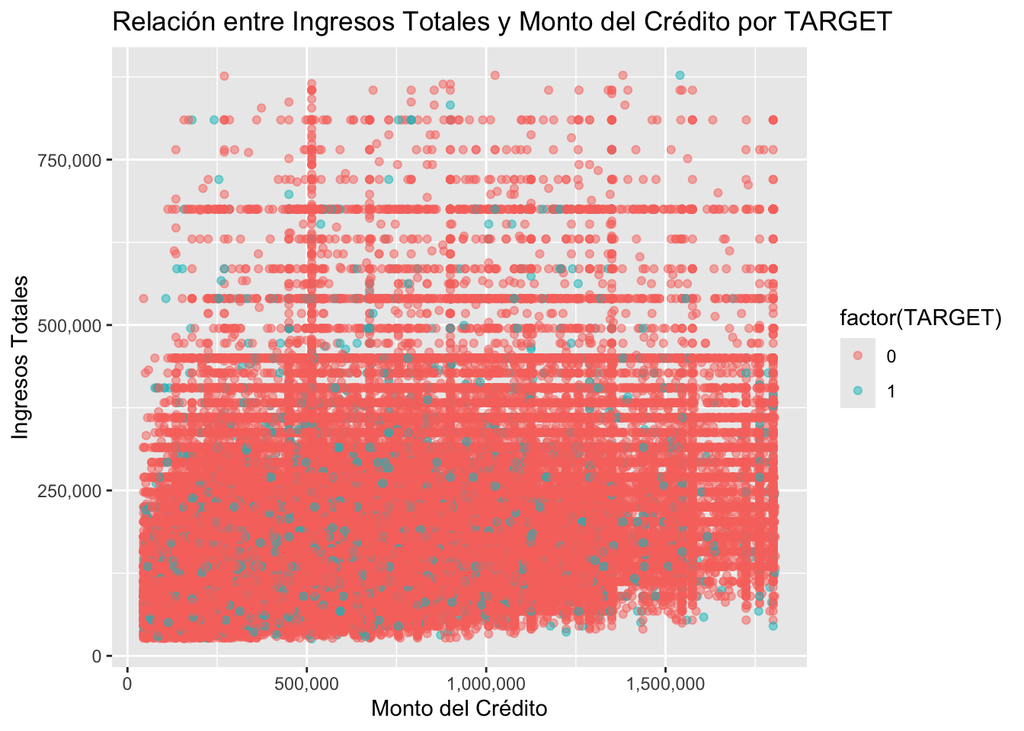

```r
ggplot(bank_application, aes(x = AMT_CREDIT, y = AMT_INCOME_TOTAL, color = factor(TARGET))) +
  geom_point(alpha = 0.5) +
  scale_x_continuous(labels = scales::comma) + scale_y_continuous(labels = scales::comma) +
  xlab("Monto del Crédito") + ylab("Ingresos Totales") +
  ggtitle("Relación entre Ingresos Totales y Monto del Crédito por TARGET")
```

#### 6. Distribución de la Edad de los Solicitantes Comparando Con y Sin Dificultades de Pago

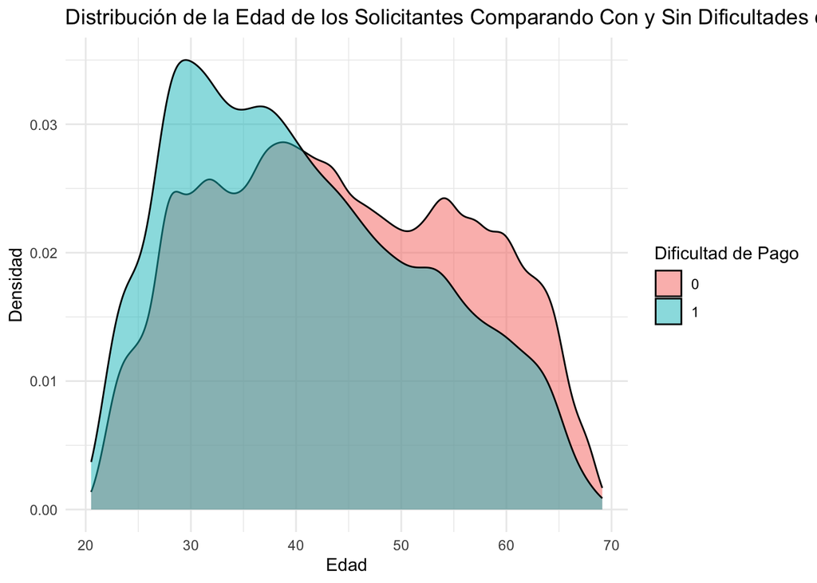

```r
ggplot(bank_application, aes(x = DAYS_BIRTH / 365, fill = as.factor(TARGET))) +
  geom_density(alpha = 0.5) +
  labs(x = "Edad", y = "Densidad", fill = "Dificultad de Pago",
       title = "Distribución de la Edad de los Solicitantes Comparando Con y Sin Dificultades de Pago") +
  theme_minimal()
```

### Transformación Necesaria

```r
data_transformed <- bank_application %>%
  mutate(
    # Logaritmo para normalizar distribuciones
    LOG_AMT_INCOME_TOTAL = log(AMT_INCOME_TOTAL),
    LOG_AMT_CREDIT = log(AMT_CREDIT),
    LOG_AMT_ANNUITY = log(AMT_ANNUITY + 1), # +1 para evitar log(0)

    # Estandarización
    Z_DAYS_BIRTH = (DAYS_BIRTH - mean(DAYS_BIRTH)) / sd(DAYS_BIRTH),
    Z_DAYS_EMPLOYED = (DAYS_EMPLOYED - mean(DAYS_EMPLOYED)) / sd(DAYS_EMPLOYED),

    # Reemplazo de outliers por mediana
    AMT_INCOME_TOTAL = ifelse(AMT_INCOME_TOTAL > quantile(AMT_INCOME_TOTAL, 0.99), median(AMT_INCOME_TOTAL), AMT_INCOME_TOTAL),

    # Convertir variables categóricas en variables dummy
    OCCUPATION_TYPE_DUMMY = as.numeric(factor(OCCUPATION_TYPE))
  )
```

## Especificación Descrita

**A partir de los resultados de EDA describir la especificación del modelo de clasificación a estimar. Brevemente, describir cómo es el posible impacto y/o relación de cada una de las variables control de interés sobre la principal variable de estudio.**

Al diseñar un modelo de clasificación para predecir la capacidad de un solicitante de cumplir con sus obligaciones crediticias (`TARGET`), las siguientes variables se perfilan como relevantes según el EDA:

- **Edad (DAYS_BIRTH)**: Al observar la edad de los solicitantes, podríamos esperar que los más jóvenes, aún sin establecer un historial crediticio sólido, puedan tener más probabilidades de incumplimiento. Por otro lado, los solicitantes mayores podrían ser más estables financieramente y tener menos probabilidades de incumplimiento.
- **Estabilidad laboral (DAYS_EMPLOYED)**: Un período más largo de empleo podría indicar estabilidad financiera y ser un indicador de menor riesgo, sugiriendo una menor probabilidad de incumplimiento en el pago de créditos.
- **Ingresos Totales (AMT_INCOME_TOTAL)**: Los ingresos altos podrían estar asociados con una mayor capacidad para cumplir con las obligaciones de crédito, aunque esto debe evaluarse en relación con el monto del crédito otorgado.
- **Cantidad de Crédito (AMT_CREDIT)**: Montos más altos de crédito podrían estar asociados con un mayor riesgo, especialmente si los ingresos del solicitante no son proporcionalmente altos.
- **Cantidad de Hijos (CNT_CHILDREN)**: Los solicitantes con hijos podrían tener más gastos y, por lo tanto, podrían tener un riesgo ligeramente mayor de incumplimiento debido a la presión financiera adicional.
- **Historial Crediticio (EXT_SOURCE, si está disponible)**: Los puntajes de crédito externos bajos pueden indicar un historial de pagos deficientes, aumentando la probabilidad de incumplimiento.
- **Tipo de Ingreso (NAME_INCOME_TYPE)**: Algunas categorías de ingresos, como los trabajadores por cuenta propia, podrían mostrar un comportamiento de riesgo diferente en comparación con los empleados con sueldos fijos debido a la variabilidad de sus ingresos.

El impacto de cada variable será evaluado a través de la significancia de sus coeficientes en el modelo y su contribución a la precisión de las predicciones. Además, si bien la correlación entre las variables y `TARGET` no mostro impactos directos durante el analisis de la matriz de correlación, dichos impactos pueden pasar inadvertidos debido a su naturaleza no lineal o interacciones con otras variables. Por lo tanto, se emplearán técnicas de modelización que puedan capturar efectos no lineales y de interacción, como árboles de decisión, modelos de ensamble o redes neuronales, que pueden revelar relaciones complejas y ofrecer una mejor interpretación del riesgo crediticio.

## Modelos de Clasificación

Estimación de cada uno de los siguientes modelos de Supervised Machine Learning - Clasificación:

### Preparaciones Previas

```r
# Primero, crearemos una partición para los datos de entrenamiento y prueba
set.seed(123)

data_partition <- createDataPartition(data_transformed$TARGET, p = 0.8, list = FALSE)
training_set <- bank_application[data_partition, ]
test_set <- bank_application[-data_partition, ]
```

### a. Logistic Regression

```r
# Ajustamos el modelo de regresión logística
logit_model <- glm(TARGET ~ CODE_GENDER + FLAG_OWN_CAR + FLAG_OWN_REALTY + CNT_CHILDREN +
                   AMT_INCOME_TOTAL + AMT_CREDIT + AMT_ANNUITY + AMT_GOODS_PRICE +
                   DAYS_BIRTH + DAYS_EMPLOYED + EXT_SOURCE_2 + EXT_SOURCE_3,
                   data = training_set, family = "binomial")

# Hacemos predicciones en el conjunto de prueba
predictions <- predict(logit_model, test_set, type = "response")
predicted_class <- ifelse(predictions > 0.5, 1, 0)
```

```r
summary(logit_model)
```

```
##
## Call:
## glm(formula = TARGET ~ CODE_GENDER + FLAG_OWN_CAR + FLAG_OWN_REALTY +
##     CNT_CHILDREN + AMT_INCOME_TOTAL + AMT_CREDIT + AMT_ANNUITY +
##     AMT_GOODS_PRICE + DAYS_BIRTH + DAYS_EMPLOYED + EXT_SOURCE_2 +
##     EXT_SOURCE_3, family = "binomial", data = training_set)
##
## Coefficients:
##                    Estimate Std. Error z value Pr(>|z|)
## (Intercept)       3.168e-01  4.258e-02   7.439 1.01e-13 ***
## CODE_GENDERM      4.649e-01  1.677e-02  27.726  < 2e-16 ***
## CODE_GENDERXNA   -6.797e+00  4.142e+01  -0.164  0.86966
## FLAG_OWN_CARY    -3.060e-01  1.773e-02 -17.264  < 2e-16 ***
## FLAG_OWN_REALTYY  5.111e-02  1.664e-02   3.072  0.00212 **
## CNT_CHILDREN      1.482e-02  1.062e-02   1.395  0.16289
## AMT_INCOME_TOTAL -1.417e-06  1.121e-07 -12.644  < 2e-16 ***
## AMT_CREDIT        6.965e-07  6.572e-08  10.598  < 2e-16 ***
## AMT_ANNUITY       1.208e-05  9.239e-07  13.078  < 2e-16 ***
## AMT_GOODS_PRICE  -1.096e-06  7.380e-08 -14.852  < 2e-16 ***
## DAYS_BIRTH       -2.084e-05  2.298e-06  -9.069  < 2e-16 ***
## DAYS_EMPLOYED    -6.336e-07  7.965e-08  -7.955 1.79e-15 ***
## EXT_SOURCE_2     -2.420e+00  3.722e-02 -65.008  < 2e-16 ***
## EXT_SOURCE_3     -2.740e+00  4.187e-02 -65.430  < 2e-16 ***
## ---
## Signif. codes:  0 '***' 0.001 '**' 0.01 '*' 0.05 '.' 0.1 ' ' 1
##
## (Dispersion parameter for binomial family taken to be 1)
##
##     Null deviance: 138165  on 246008  degrees of freedom
## Residual deviance: 125942  on 245995  degrees of freedom
## AIC: 125970
##
## Number of Fisher Scoring iterations: 8
```

#### Evaluación del Modelo

- **Matriz de Confusión**

```r
# Creamos la matriz de confusión
confusionMatrix <- confusionMatrix(factor(predicted_class), factor(test_set$TARGET))
confusionMatrix
```

```
## Confusion Matrix and Statistics
##
##           Reference
## Prediction     0     1
##          0 56527  4920
##          1    37    18
##
##                Accuracy : 0.9194
##                  95% CI : (0.9172, 0.9215)
##     No Information Rate : 0.9197
##     P-Value [Acc > NIR] : 0.6146
##
##                   Kappa : 0.0055
##
##  Mcnemar's Test P-Value : <2e-16
##
##             Sensitivity : 0.999346
##             Specificity : 0.003645
##          Pos Pred Value : 0.919931
##          Neg Pred Value : 0.327273
##              Prevalence : 0.919710
##          Detection Rate : 0.919108
##    Detection Prevalence : 0.999106
##       Balanced Accuracy : 0.501496
##
##        'Positive' Class : 0
##
```

- **Estadístico Kappa**

```r
# Estadístico Kappa
kappa_stat <- kappa(confusionMatrix$table)

# Extraer el valor del Estadístico Kappa desde el componente correcto
kappa_value <- kappa_stat$coef

# Asegurarse de convertir a numérico, aunque esto puede ser redundante si ya es numérico
kappa_value_numeric <- as.numeric(kappa_value)

# Imprimir el Estadístico Kappa
cat("Estadístico Kappa:", kappa_value_numeric, "\n")
```

```
## Estadístico Kappa: 0.005450878
```

- **AUC**

```r
# Calculamos AUC
roc_obj <- roc(response = test_set$TARGET, predictor = predictions)
auc_statistic <- auc(roc_obj)
auc_statistic
```

```
## Area under the curve: 0.7275
```

- **ROC Curve**

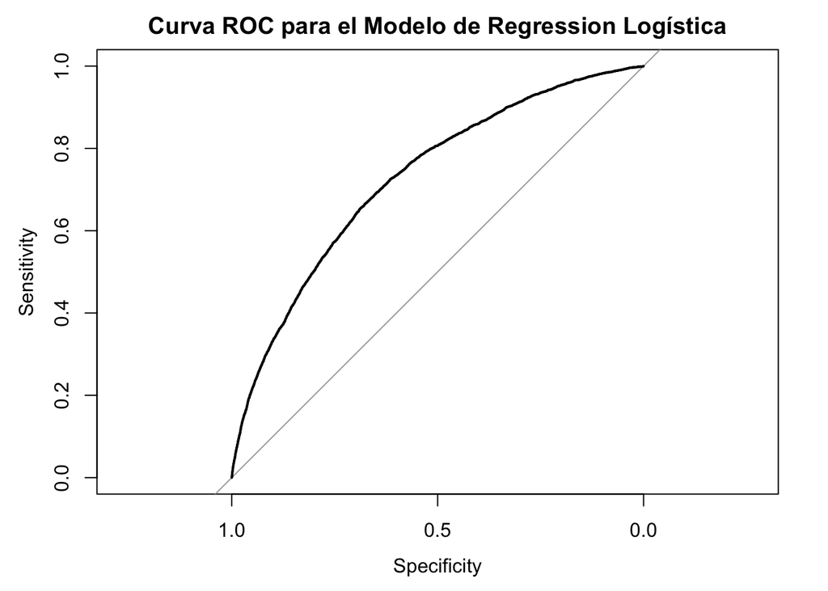

```r
# Dibujamos la curva ROC
plot(roc_obj, main="Curva ROC para el Modelo de Regression Logística")
```

### b. Decision Trees

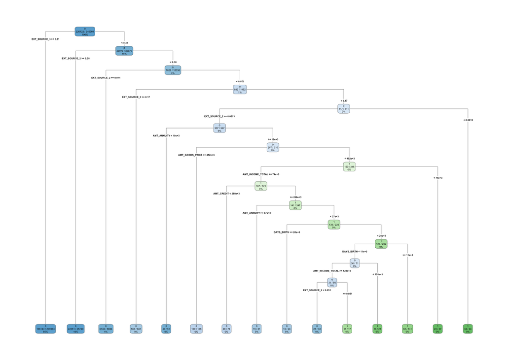

```r
# Ajustar el modelo CART con las mismas variables que la regresión logística
cart_model <- rpart(TARGET ~ CODE_GENDER + FLAG_OWN_CAR + FLAG_OWN_REALTY + CNT_CHILDREN +
                    AMT_INCOME_TOTAL + AMT_CREDIT + AMT_ANNUITY + AMT_GOODS_PRICE +
                    DAYS_BIRTH + DAYS_EMPLOYED + EXT_SOURCE_2 + EXT_SOURCE_3,
                    data = training_set,
                    method = "class",
                    control = rpart.control(minsplit = 10, cp = 0.000241))

# Hacer predicciones en el conjunto de prueba y seleccionar la clase con mayor probabilidad
cart_predictions <- predict(cart_model, newdata = test_set, type = "prob")
cart_predicted_class <- ifelse(cart_predictions[,2] > 0.5, 1, 0)

# Visualizar el árbol de decisión
rpart.plot(cart_model, type = 4, extra = 102)
```

#### Evaluación del Modelo

- **Matriz de Confusión**

```r
# Matriz de Confusión
confusionMatrix <- confusionMatrix(factor(cart_predicted_class), factor(test_set$TARGET))
print(confusionMatrix)
```

```
## Confusion Matrix and Statistics
##
##           Reference
## Prediction     0     1
##          0 56542  4913
##          1    22    25
##
##                Accuracy : 0.9198
##                  95% CI : (0.9176, 0.9219)
##     No Information Rate : 0.9197
##     P-Value [Acc > NIR] : 0.486
##
##                   Kappa : 0.0085
##
##  Mcnemar's Test P-Value : <2e-16
##
##             Sensitivity : 0.999611
##             Specificity : 0.005063
##          Pos Pred Value : 0.920055
##          Neg Pred Value : 0.531915
##              Prevalence : 0.919710
##          Detection Rate : 0.919352
##    Detection Prevalence : 0.999236
##       Balanced Accuracy : 0.502337
##
##        'Positive' Class : 0
##
```

- **Estadístico Kappa**

```r
# Estadístico Kappa
kappa_stat <- kappa(confusionMatrix$table)

# Extraer el valor del Estadístico Kappa desde el componente correcto
kappa_value <- kappa_stat$coef

# Asegurarse de convertir a numérico, aunque esto puede ser redundante si ya es numérico
kappa_value_numeric <- as.numeric(kappa_value)

# Imprimir el Estadístico Kappa
cat("Estadístico Kappa:", kappa_value_numeric, "\n")
```

```
## Estadístico Kappa: 0.008529008
```

- **AUC**

```r
# AUC
roc_result <- roc(response = test_set$TARGET, predictor = cart_predictions[,2])
auc_result <- auc(roc_result)
print(auc_result)
```

```
## Area under the curve: 0.5925
```

- **ROC Curve**

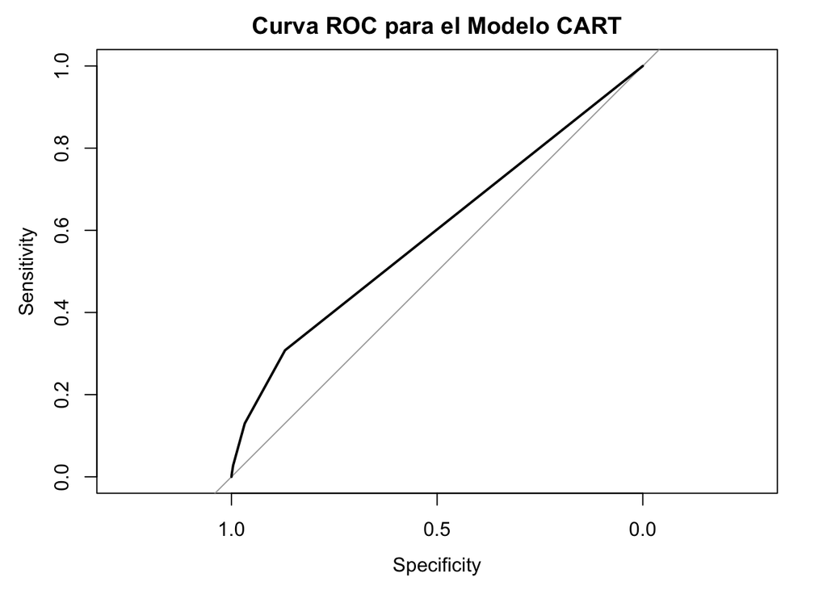

```r
# ROC Curve
plot(roc_result, main="Curva ROC para el Modelo CART")
```

```r
# Ajustar el modelo SVM con un kernel lineal y especificando un valor de costo C
# svm_model <- svm(TARGET ~ CODE_GENDER + FLAG_OWN_CAR + FLAG_OWN_REALTY + CNT_CHILDREN +
#                 AMT_INCOME_TOTAL + AMT_CREDIT + AMT_ANNUITY + AMT_GOODS_PRICE +
#                 DAYS_BIRTH + DAYS_EMPLOYED + EXT_SOURCE_2 + EXT_SOURCE_3,
#                 data = training_set,
#                 method = "C-classification",
#                 kernel = "linear",  # Cambiado a kernel lineal
#                 cost = 1)  # Valor de costo C, ajusta según sea necesario

# Hacer predicciones en el conjunto de prueba
# svm_predictions <- predict(svm_model, test_set)
```

#### Evaluación del Modelo

- **Matriz de Confusión**

```r
# Matriz de Confusión
# confusionMatrix <- confusionMatrix(as.factor(svm_predictions), as.factor(test_labels))
# print(confusionMatrix)
```

- **Estadístico Kappa**

```r
# Estadístico Kappa
# kappa_stat <- kappa(confusionMatrix$table)

# Extraer el valor del Estadístico Kappa desde el componente correcto
# kappa_value <- kappa_stat$coef

# Asegurarse de convertir a numérico, aunque esto puede ser redundante si ya es numérico
# kappa_value_numeric <- as.numeric(kappa_value)

# Imprimir el Estadístico Kappa
# cat("Estadístico Kappa:", kappa_value_numeric, "\n")
```

- **AUC**

```r
# Convertir las predicciones en probabilidades para la ROC
# svm_probs <- predict(svm_model, test_set, probability = TRUE)
# svm_probs <- attr(svm_probs, "probabilities")[,2]

# AUC
# roc_response <- roc(response = test_set$TARGET, predictor = svm_probs)
# auc_value <- auc(roc_response)
# cat("AUC:", auc_value, "\n")
```

- **ROC Curve**

```r
# ROC Curve
# plot(roc_response, main = "ROC Curve for SVM Model")
```

### d. K – Means Clustering

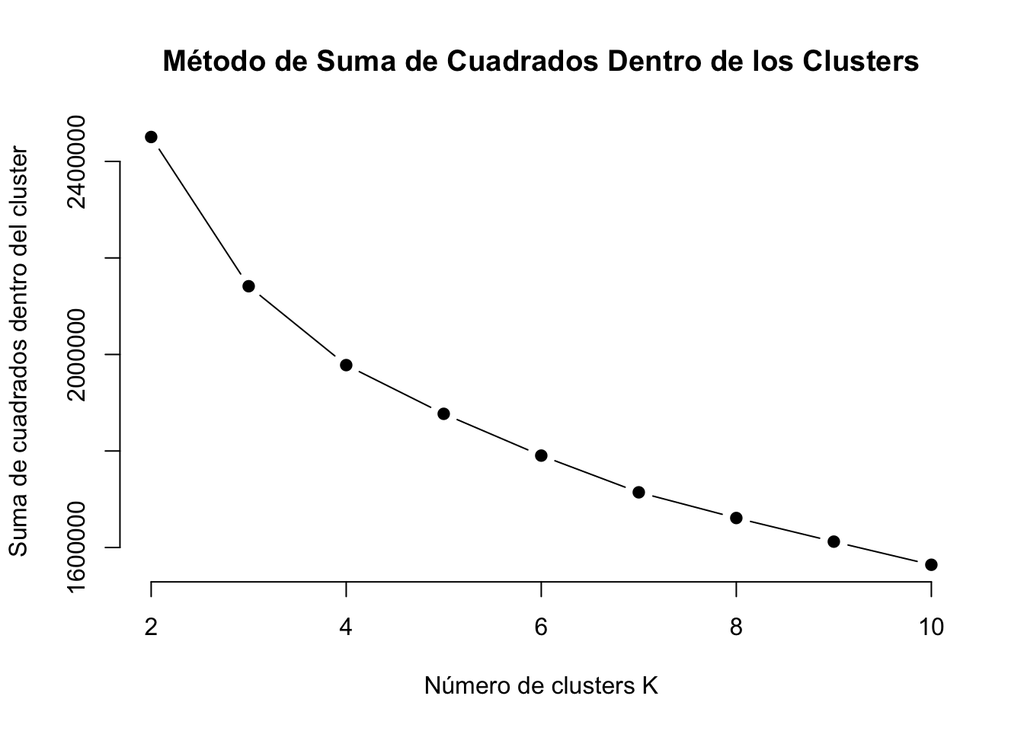

```r
# Copiando los DataFrames para mantener los originales intactos
training_set_copy <- training_set
test_set_copy <- test_set

# Transformando variables categóricas en numéricas en las copias
for (var in c("CODE_GENDER", "FLAG_OWN_CAR", "FLAG_OWN_REALTY")) {
  training_set_copy[[var]] <- as.numeric(as.factor(training_set_copy[[var]]))
  test_set_copy[[var]] <- as.numeric(as.factor(test_set_copy[[var]]))
}

# Seleccionando variables para el clustering en la copia del conjunto de entrenamiento
variables_clustering <- c("CODE_GENDER", "FLAG_OWN_CAR", "FLAG_OWN_REALTY", "CNT_CHILDREN",
                          "AMT_INCOME_TOTAL", "AMT_CREDIT", "AMT_ANNUITY", "AMT_GOODS_PRICE",
                          "DAYS_BIRTH", "DAYS_EMPLOYED", "EXT_SOURCE_2", "EXT_SOURCE_3")

datos_clustering <- training_set_copy[, variables_clustering]

# Escalando los datos para el clustering
datos_clustering_scaled <- scale(datos_clustering)

# Aplicando PCA antes del clustering
pca_res <- prcomp(datos_clustering_scaled, center = TRUE, scale. = TRUE)
datos_clustering_pca <- predict(pca_res, datos_clustering_scaled)

# Calculando la suma de cuadrados dentro de los clusters para diferentes valores de k
set.seed(123) # Para reproducibilidad
ssw <- sapply(2:10, function(k) {
  kmeans(datos_clustering_pca, centers = k, nstart = 25)$tot.withinss
})

# Creando un vector de valores k (no incluimos k = 1 ya que no es útil para el método del codo)
k_values <- 2:10

# Graficando el método del codo
plot(k_values, ssw, type = "b", pch = 19, frame = FALSE,
     xlab = "Número de clusters K",
     ylab = "Suma de cuadrados dentro del cluster")
title(main = "Método de Suma de Cuadrados Dentro de los Clusters")
```

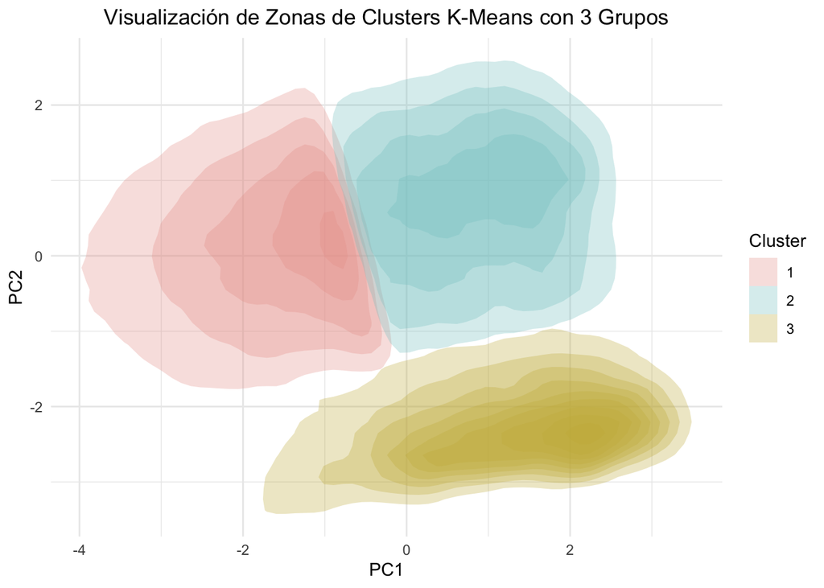

```r
# Configurar la semilla para reproducibilidad
set.seed(123)

# Ejecutar K-Means para agrupar los datos en 3 clusters
kmeans_result_3 <- kmeans(datos_clustering_scaled, centers = 3, nstart = 25)

# Realizar PCA en los datos escalados
pca_result <- prcomp(datos_clustering_scaled)

# Crear un data frame con los resultados de los clusters y los componentes principales para la visualización
pca_data <- data.frame(PC1 = pca_result$x[, 1], PC2 = pca_result$x[, 2], cluster = as.factor(kmeans_result_3$cluster))

# Usar ggplot2 para crear el gráfico de los clusters utilizando los componentes principales
ggplot(pca_data, aes(x = PC1, y = PC2, fill = cluster)) +
  stat_density_2d(geom = "polygon", aes_string(x = "PC1", y = "PC2", fill = "cluster"),
                  size = 0.01, bins = 10, contour = TRUE, alpha = 0.3) +  # Ajustamos la transparencia con alpha
  scale_fill_manual(values = c("#E79C95", "#7EC8C8", "#C7B446")) +
  theme_minimal() +
  labs(fill="Cluster") +
  ggtitle("Visualización de Zonas de Clusters K-Means con 3 Grupos") +
  theme(legend.position = "right", plot.title = element_text(hjust = 0.5))
```

### e. KNN

```r
# Asegurarse de que test_set_copy tiene la misma estructura que datos_clustering_scaled
test_set_copy_scaled <- scale(test_set_copy[, variables_clustering])

# Definir la variable objetivo para el conjunto de entrenamiento y prueba
training_labels <- training_set_copy$TARGET
test_labels <- test_set_copy$TARGET

# Asegurarnos de tener conjuntos de datos normalizados para el modelo KNN
test_set_copy_scaled <- as.data.frame(scale(test_set_copy[, variables_clustering], center = attr(datos_clustering_scaled, "scaled:center"), scale = attr(datos_clustering_scaled, "scaled:scale")))

# Entrenar el modelo KNN
set.seed(123)
k <- 5 # Elegir un valor para k, el número de vecinos
knn_pred <- knn(train = datos_clustering_scaled, test = test_set_copy_scaled, cl = training_labels, k = k)
```

#### Evaluación del Modelo

- **Matriz de Confusión**

```r
# Matriz de Confusión
confusionMatrix <- confusionMatrix(as.factor(knn_pred), as.factor(test_labels))
print(confusionMatrix)
```

```
## Confusion Matrix and Statistics
##
##           Reference
## Prediction     0     1
##          0 55878  4712
##          1   686   226
##
##                Accuracy : 0.9122
##                  95% CI : (0.91, 0.9145)
##     No Information Rate : 0.9197
##     P-Value [Acc > NIR] : 1
##
##                   Kappa : 0.0536
##
##  Mcnemar's Test P-Value : <2e-16
##
##             Sensitivity : 0.98787
##             Specificity : 0.04577
##          Pos Pred Value : 0.92223
##          Neg Pred Value : 0.24781
##              Prevalence : 0.91971
##          Detection Rate : 0.90856
##    Detection Prevalence : 0.98517
##       Balanced Accuracy : 0.51682
##
##        'Positive' Class : 0
##
```

- **Estadístico Kappa**

```r
# Estadístico Kappa
kappa_stat <- kappa(confusionMatrix$table)

# Extraer el valor del Estadístico Kappa desde el componente correcto
kappa_value <- kappa_stat$coef

# Asegurarse de convertir a numérico, aunque esto puede ser redundante si ya es numérico
kappa_value_numeric <- as.numeric(kappa_value)

# Imprimir el Estadístico Kappa
cat("Estadístico Kappa:", kappa_value_numeric, "\n")
```

```
## Estadístico Kappa: 0.05357205
```

- **AUC**

```r
# AUC y Curva ROC
roc_response <- roc(response = as.numeric(as.character(test_labels)), predictor = as.numeric(as.character(knn_pred)))
auc_value <- auc(roc_response)
cat("AUC:", auc_value, "\n")
```

```
## AUC: 0.5168198
```

- **ROC Curve**

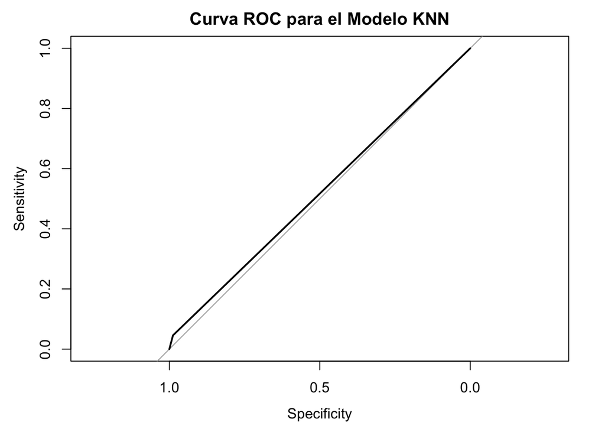

```r
# Dibujamos la curva ROC
plot(roc_response, main = "Curva ROC para el Modelo KNN")
```

### f. Naïve Bayes

```r
# Entrenar el modelo Naive Bayes
nb_model <- naiveBayes(TARGET ~ CODE_GENDER + FLAG_OWN_CAR + FLAG_OWN_REALTY + CNT_CHILDREN +
                       AMT_INCOME_TOTAL + AMT_CREDIT + AMT_ANNUITY + AMT_GOODS_PRICE +
                       DAYS_BIRTH + DAYS_EMPLOYED + EXT_SOURCE_2 + EXT_SOURCE_3,
                       data = training_set)

# Hacer predicciones en el conjunto de prueba
nb_predictions <- predict(nb_model, newdata = test_set)
nb_predictions_raw <- predict(nb_model, newdata = test_set, type = "raw")
```

#### Evaluación del Modelo

- **Matriz de Confusión**

```r
# Matriz de Confusión
confusionMatrix <- confusionMatrix(as.factor(nb_predictions), as.factor(test_set$TARGET))
confusionMatrix_data <- confusionMatrix(as.factor(nb_predictions), as.factor(test_set$TARGET))
print(confusionMatrix)
```

```
## Confusion Matrix and Statistics
##
##           Reference
## Prediction     0     1
##          0 55341  4366
##          1  1223   572
##
##                Accuracy : 0.9091
##                  95% CI : (0.9068, 0.9114)
##     No Information Rate : 0.9197
##     P-Value [Acc > NIR] : 1
##
##                   Kappa : 0.1328
##
##  Mcnemar's Test P-Value : <2e-16
##
##             Sensitivity : 0.9784
##             Specificity : 0.1158
##          Pos Pred Value : 0.9269
##          Neg Pred Value : 0.3187
##              Prevalence : 0.9197
##          Detection Rate : 0.8998
##    Detection Prevalence : 0.9708
##       Balanced Accuracy : 0.5471
##
##        'Positive' Class : 0
##
```

- **Estadístico Kappa**

```r
# Estadístico Kappa
kappa_stat <- kappa(confusionMatrix$table)

# Extraer el valor del Estadístico Kappa desde el componente correcto
kappa_value <- kappa_stat$coef

# Asegurarse de convertir a numérico, aunque esto puede ser redundante si ya es numérico
kappa_value_numeric <- as.numeric(kappa_value)

# Imprimir el Estadístico Kappa
cat("Estadístico Kappa:", kappa_value_numeric, "\n")
```

```
## Estadístico Kappa: 0.1327837
```

- **AUC**

```r
# Calcular AUC
roc_obj <- roc(response = as.numeric(test_set$TARGET), predictor = nb_predictions_raw[,2])
auc_value <- auc(roc_obj)
cat("El valor AUC es:", auc_value, "\n")
```

```
## El valor AUC es: 0.69371
```

- **ROC Curve**

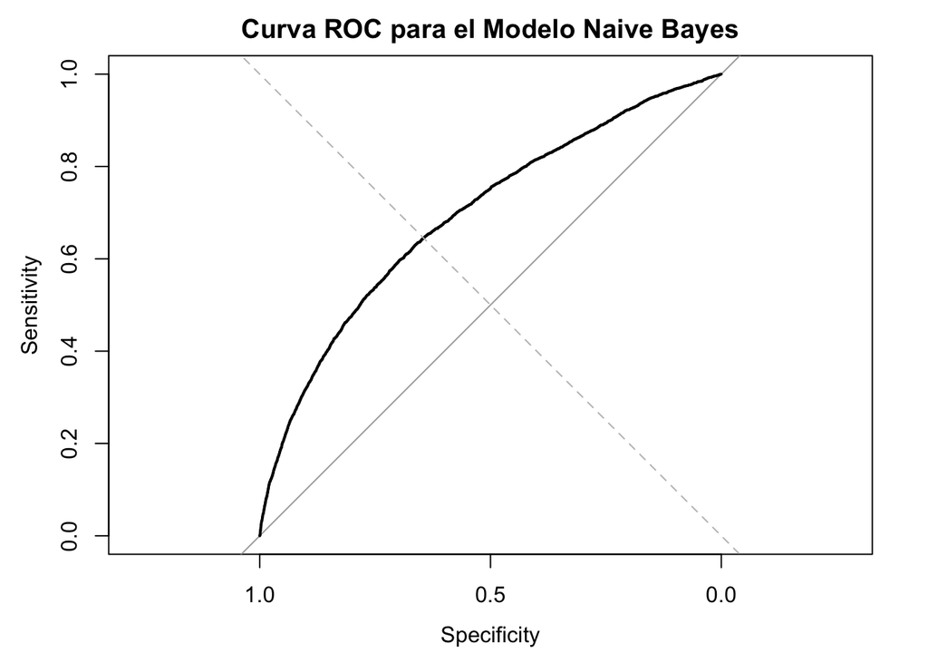

```r
# Curva ROC
plot(roc_obj, main = "Curva ROC para el Modelo Naive Bayes", lwd = 2)
abline(a = 0, b = 1, lty = 2, col = "gray")
```

### g. Random Forest

```r
# Entrenar el modelo Random Forest
training_set$TARGET <- as.factor(training_set$TARGET)

rf_model <- randomForest(TARGET ~ CODE_GENDER + FLAG_OWN_CAR + FLAG_OWN_REALTY + CNT_CHILDREN +
                         AMT_INCOME_TOTAL + AMT_CREDIT + AMT_ANNUITY + AMT_GOODS_PRICE +
                         DAYS_BIRTH + DAYS_EMPLOYED + EXT_SOURCE_2 + EXT_SOURCE_3,
                         data = training_set, ntree = 100, mtry = 3, importance = TRUE)

# Hacer predicciones en el conjunto de prueba
rf_predictions <- predict(rf_model, newdata = test_set)

# Generar predicciones probabilísticas para la clase de interés
rf_predictions_prob <- predict(rf_model, newdata = test_set, type = "prob")[,2]
```

#### Evaluación del Modelo

- **Matriz de Confusión**

```r
confusionMatrix <- confusionMatrix(as.factor(rf_predictions), as.factor(test_set$TARGET))
print(confusionMatrix)
```

```
## Confusion Matrix and Statistics
##
##           Reference
## Prediction     0     1
##          0 56515  4884
##          1    49    54
##
##                Accuracy : 0.9198
##                  95% CI : (0.9176, 0.9219)
##     No Information Rate : 0.9197
##     P-Value [Acc > NIR] : 0.4742
##
##                   Kappa : 0.0182
##
##  Mcnemar's Test P-Value : <2e-16
##
##             Sensitivity : 0.99913
##             Specificity : 0.01094
##          Pos Pred Value : 0.92045
##          Neg Pred Value : 0.52427
##              Prevalence : 0.91971
##          Detection Rate : 0.91891
##    Detection Prevalence : 0.99833
##       Balanced Accuracy : 0.50503
##
##        'Positive' Class : 0
##
```

- **Estadístico Kappa**

```r
# Estadístico Kappa
kappa_stat <- kappa(confusionMatrix$table)

# Extraer el valor del Estadístico Kappa desde el componente correcto
kappa_value <- kappa_stat$coef

# Asegurarse de convertir a numérico, aunque esto puede ser redundante si ya es numérico
kappa_value_numeric <- as.numeric(kappa_value)

# Imprimir el Estadístico Kappa
cat("Estadístico Kappa:", kappa_value_numeric, "\n")
```

```
## Estadístico Kappa: 0.018203
```

- **AUC**

```r
# Calcular AUC
roc_obj_rf <- roc(as.numeric(test_set$TARGET), rf_predictions_prob)
auc_value_rf <- auc(roc_obj_rf)
cat("El valor AUC para Random Forest es:", auc_value_rf, "\n")
```

```
## El valor AUC para Random Forest es: 0.7065056
```

- **ROC Curve**

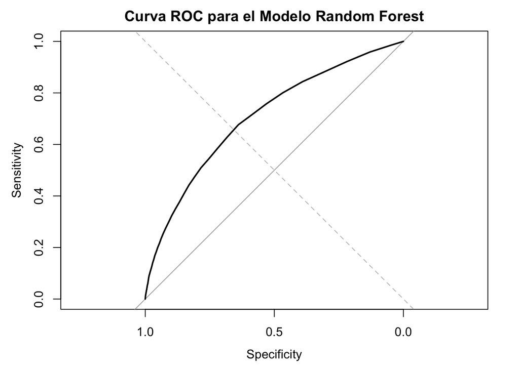

```r
# Curva ROC
plot(roc_obj_rf, main = "Curva ROC para el Modelo Random Forest")
abline(a = 0, b = 1, lty = 2, col = "gray")
```

## Evaluación y Selección de Modelo de Clasificación

### Insights Clave de los Modelos

#### Regresión Logística

- **Desempeño General**: Con un AUC de 0.7275, la regresión logística tiene un rendimiento moderado en la distinción entre las clases.
- **Coeficientes Significativos**: `CODE_GENDER`, `FLAG_OWN_CAR`, y las fuentes externas (`EXT_SOURCE_2`, `EXT_SOURCE_3`) son predictores significativos de la dificultad de pago.
- **Baja Sensibilidad**: El modelo tiene una especificidad cercana a cero, lo que indica una baja sensibilidad para detectar la clase positiva.

#### Árboles de Decisión (CART)

- **AUC Inferior**: Con un AUC de 0.5925, sugiere una capacidad limitada para diferenciar entre las clases en comparación con otros modelos.
- **Balance**: Pese a su menor AUC, los árboles de decisión pueden ser más fáciles de interpretar y explicar.

#### K-Vecinos Más Cercanos (KNN)

- **Cercanía al Azar**: Un AUC de 0.5168 indica que el modelo está actuando apenas mejor que un lanzamiento de moneda al azar en este conjunto de datos.

#### Naive Bayes

- **Rendimiento Mejorado**: Con un AUC de 0.6937, Naive Bayes muestra un mejor rendimiento que KNN pero aún es inferior a la regresión logística.
- **Predicciones Equilibradas**: A pesar de su sencillez, presenta un mejor equilibrio entre sensibilidad y especificidad comparado con la regresión logística.

## Conclusiones y Análisis

Los modelos de clasificación evaluados muestran un rango diverso de rendimientos y características. La elección final del modelo debe basarse no solo en la precisión, sino también en la capacidad de interpretación de los resultados.

La **regresión logística** ofrece una interpretación clara de las relaciones entre las variables y la probabilidad de incumplimiento en pagos, a pesar de su sensibilidad limitada. Su AUC de 0.7275 sugiere que hay espacio para mejorar en términos de distinguir entre las clases.

El desempeño de **KNN** está cerca del azar, lo que sugiere que no es adecuado para este problema particular, quizás debido a la alta dimensionalidad de los datos o la necesidad de una métrica de distancia más refinada.

**Naive Bayes**, a pesar de su suposición de independencia entre características, ofrece un rendimiento decente y puede ser una opción rápida y robusta cuando la complejidad del modelo es una preocupación.